# Movies Report

### Introduction

In our dataset, the Movie Industry, we want to better understand the trends of the various characteristics that apply to the external and internal factors of a movie, including the budget, rating, genre, production company, runtime, and so much more. We are analyzing the dataset that spans over three decades: from 1986 - 2016. The purpose of acquiring this dataset is to observe how certain trends have increased, decreased, or stayed the same within the movie industry as it has developed over time for both producers and for the audience. An example would be comparing the gross revenue to each genre to analyze which genre generally produces the best selling movies.

[Link](https://www.kaggle.com/danielgrijalvas/movies) to the original data source at *kaggle.com*.

### Summary Information

In our Movies dataset, there are 15 columns, which are named budget, company, country, director, genre, gross, name, rating, released, runtime, score, star, votes, writer, year. The character types for each column are: numeric, character, character, character, character, numeric, character, character, character, integer, numeric, character, integer, character, integer. There are 6820 rows. The types of movie ratings included are R, PG-13, PG, UNRATED, Not specified, G, NC-17, NOT RATED, TV-PG, TV-MA, B, B15, TV-14. Understanding these characteristics of our dataset gives us a better understanding of the size of our dataset, what types of values we are working with, and an example of data we will be analyzing.

### Aggregate Summary of Dataset

[output not shown]

By grouping our data by year, we can better analyze trends according to time. Firstly, getting the median budget of movies of each year can indicate how much investment and how much work is being put into movie production. According to the data, the median budget appears to be slowly increasing, which is reflective of the growth of the movie industry over time. Secondly, getting the mean revenue of year can is also a factor we can use to analyze the success of movies as well as the growth in viewership and audience over time. Getting the top grossing movie of each year in conjunction with the rating of that movie can tell us what types of movies did extremely well and were the most popular. Lastly, figuring out the movie with the highest budget each year can help us understand how budget compares to success (in terms of revenue).

## Graphs

### Bar Graph

The four bar chart’s purpose is to compare the relationship of how the budget of each type of rating category change throughout the span of 30 years.

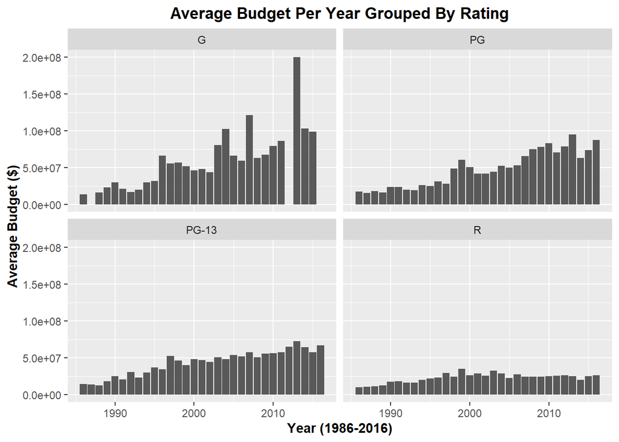

#### Important information:

- Besides the rated R category, all the categories increase the budget of the movies throughout the years.
- The rated G movie productions have a trend of acquiring a higher budget compared to the other rating categories, and the budget increases as the years progress.
- The rated R category stays at a consistent budget rate per yearly, and it is generally far lower budget compared to the other ratings.

### Line Graph

This chart aims to show and compare the prevalence of different movie ratings over the last 30 years. A line graph emphasizes the rise and falls in the data over time, and ploting the different ratings in different colors on the same graph helps to closely compare their trends.

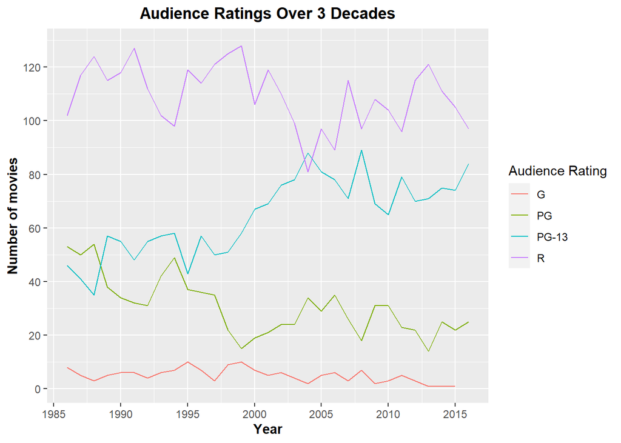

#### Important information:

- There has been a rise in PG-13 movies and a decrease in PG movies.
- The number of G movies has remained relatively steady with a very low number of films per year.
- The R movies tend to be the most frequent but their numbers fluctuate by year.

### Scatter Plot

The purpose of this scatter plot is to display the relationship between the average yearly budget and average yearly gross incomes of movies over a thirty year period.

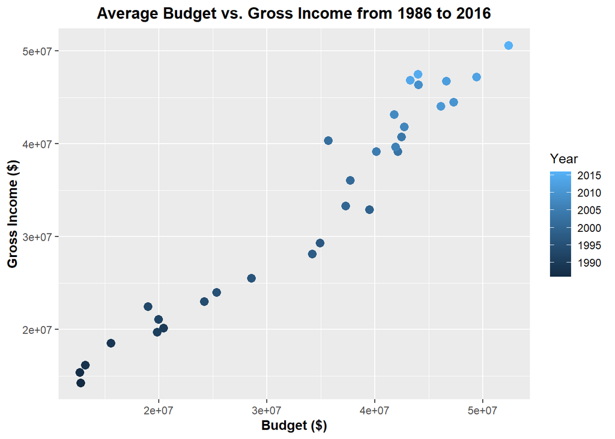

#### Important information:

- There is a linear relationship between the average annual budget and the annual gross income.
- Both the budget and gross income of movies has consistently increased over the three decade period.